# Predicting Height and Anxiety Disorder in Children Between the Ages of 6-17

- Show All Code
- Hide All Code
- View Source

How Age, Childhood Experiences, Sleep, and Family Can Contribute

Author

Brooke Bhattacharya

Published

2025-03-19

## R Packages and Setup

```r
knitr::opts_chunk$set(comment = NA)

library(janitor)
library(naniar)
library(broom)
library(car)
library(caret)
library(GGally)
library(gt)
library(gtsummary)
library(knitr)
library(mice)
library(mosaic)
library(patchwork)
library(ROCR)
library(rsample)
library(rms)
library(patchwork)
library(haven)
library(survey)
library(utils)
library(naniar)
library(ggplot2)
library(easystats)
library(tidyverse)

theme_set(theme_bw())
```

# 1 Data Source

For this project, I will be using data sourced from The National Survey of Children’s Health (NSCH), from the year 2023. The NSCH is a yearly survey focused on collecting extensive demographic, health (mental and physical), family, school, and neighborhood survey responses from children in families within America.

# 2 The Subjects

The National Survey of Children’s Health (NSCH) collects data on children 6-17 years old in the United States via questionnaire. The 2023 NSCH data were collected from June 2023 to January 2024, and consisted of information on 55,162 children, within the above mentioned age range, after screening and eligibility checks. This is also the number of completed questionnaires for the NSCH in 2023.

# 3 Loading and Tidying the Data

## 3.1 Loading the Raw Data

```r
NSCH23Url <- "https://www2.census.gov/programs-surveys/nsch/datasets/2023/nsch_2023e_topical_SAS.zip"
download.file(NSCH23Url, destfile = "NSCH23.zip", mode = "wb")
unzip("NSCH23.zip", exdir = "NSCH23")
NSCH23D <- list.files("NSCH23", full.names = TRUE)
NSCH23D <- read_sas("C:/432/Project A/NSCH23/nsch_2023e_topical.sas7bdat")
```

## 3.2 Cleaning the Data

### 3.2.1 Selecting Variables

```r
NSCH23_tibble <- NSCH23D %>%
  select(
    HHID, SC_SEX, SC_AGE_YEARS, HEIGHT, ACE3, HOURSLEEP, K2Q31A, K2Q31B, K2Q31C,
    K2Q31D, K11Q43R, K2Q33A, ACE3, MAKEFRIEND, FAMILY_R, BIRTHWT_L) %>%
  mutate(across(where(is.character), as.factor)) |>
  mutate(HHID = as.character(HHID)) |>
  as_tibble()

NSCH23_tibble <- NSCH23_tibble %>%
  arrange(HHID)
```

### 3.2.2 Working with Categorical Predictors

```r
NSCH23 <- NSCH23_tibble %>%
  mutate(
    K2Q31A = fct_recode(factor(K2Q31A), "Yes" = "1"),
    K2Q31B = fct_recode(factor(K2Q31B), "Yes" = "1"),
    SC_SEX = fct_recode(factor(SC_SEX), "Male" = "1", "Female" = "2")) %>%
  filter(
    K2Q31A == "Yes",
    K2Q31B == "Yes",
    SC_SEX == "Female",
    SC_AGE_YEARS >= 6,
    SC_AGE_YEARS <= 17)

NSCH23 <- NSCH23 %>%
  mutate(
    HOURSLEEP = case_when(
      HOURSLEEP %in% c(1, 2, 3) ~ "Low",
      HOURSLEEP %in% c(4, 5) ~ "Ideal",
      HOURSLEEP %in% c(6, 7) ~ "High"),
    HOURSLEEP = factor(HOURSLEEP),
    FAMILY_R = case_when(
      FAMILY_R %in% c(1, 3) ~ "Married",
      FAMILY_R %in% c(2, 4) ~ "Unmarried",
      FAMILY_R %in% c(5, 6) ~ "Single",
      FAMILY_R %in% c(7, 8) ~ "Other"),
    FAMILY_R = factor(FAMILY_R),
    MAKEFRIEND = case_when(
      MAKEFRIEND == 1 ~ "None",
      MAKEFRIEND %in% c(2, 3) ~ "Difficulty"),
        MAKEFRIEND = factor(MAKEFRIEND),
    K2Q31C = fct_recode(factor(K2Q31C), "Mild" = "1", "Moderate" = "2", "Severe" = "3"),
    K2Q31D = fct_recode(factor(K2Q31D), "Yes" = "1", "No" = "2"),
    K2Q33A = fct_recode(factor(K2Q33A), "Yes" = "1", "No" = "2"),
    ACE3 = fct_recode(factor(ACE3), "Yes" = "1", "No" = "2"),
    BIRTHWT_L = fct_recode(factor(BIRTHWT_L), "Yes" = "1", "No" = "2"))


NSCH23 <- NSCH23 %>%
  mutate(HOURSLEEP=fct_relevel(HOURSLEEP,c("Low", "Ideal", "High"))) %>%
  mutate(FAMILY_R = fct_relevel(FAMILY_R, c("Married","Unmarried", "Single", "Other")))
```

In my Project A Plan, I had not consolidated HOURSLEEP. It had an appropriate amount of values and fit the requirements of the linear regression plan and analyses, but upon getting further into the Portfolio, I found that its levels were fairly unbalanced. This seemed to prohibit its ability to produce fair results in the linear regression models in later sections. Because of this, I consolidated it to consist of only three levels: “Low”, “Ideal” and “High.” Similarly, due to the same issue, I consolidated MAKEFRIEND to just “None” and “Difficulty” due to issues with unbalanced levels when it had its previous three levels. I had considered converting HEIGHT to inches from centimeters, but ultimately stuck with centimeters due to readability and more easily interpretable effects.

```r
NSCH23 %>%
  count(FAMILY_R) %>%
  filter(n < 30)
```

```
# A tibble: 0 × 2
# ℹ 2 variables: FAMILY_R <fct>, n <int>
```

```r
NSCH23 %>%
  count(HOURSLEEP) %>%
  filter(n < 30)
```

```
# A tibble: 1 × 2
  HOURSLEEP     n
  <fct>     <int>
1 <NA>         12
```

```r
NSCH23 %>%
  count(MAKEFRIEND) %>%
  filter(n < 30)
```

```
# A tibble: 1 × 2
  MAKEFRIEND     n
  <fct>      <int>
1 <NA>          12
```

```r
NSCH23 %>%
  count(K2Q31C) %>%
  filter(n < 30)
```

```
# A tibble: 1 × 2
  K2Q31C     n
  <fct>  <int>
1 <NA>      11
```

### 3.2.3 Changing Variable Names

```r
NSCH23 <- NSCH23 %>%
  zap_label() %>%
  janitor::clean_names() %>%
  rename(sex = sc_sex,
         age = sc_age_years,
         height = height,
         divorce = ace3,
         sleep = hoursleep,
         dx_past = k2q31a,
         dx_now = k2q31b,
         severity = k2q31c,
         meds = k2q31d,
         anxiety = k2q33a,
         friends = makefriend,
         family = family_r,
         moves = k11q43r,
         under_wt = birthwt_l)
```

### 3.2.4 Sampling the Data

No sampling was needed in this case as the total observations of the complete NSCH23 table (1715) is well below the 2000 observation limit.

## 3.3 Finalizing Tibble

```r
NSCH23 <- NSCH23 %>%
  select(hhid, age, height, under_wt, dx_past, dx_now,
         severity, meds, anxiety, sleep, divorce, friends, family, moves)
```

# 4 The Tidy Tibble

## 4.1 Listing the Tibble

```r
NSCH23
```

```
# A tibble: 1,715 × 14
   hhid       age height under_wt dx_past dx_now severity meds  anxiety sleep
   <chr>    <dbl>  <dbl> <fct>    <fct>   <fct>  <fct>    <fct> <fct>   <fct>
 1 23000001     8   152. No       Yes     Yes    Moderate Yes   No      High
 2 23000339    12   160. No       Yes     Yes    Moderate No    No      Low
 3 23001182    16   155. No       Yes     Yes    Mild     Yes   Yes     Ideal
 4 23001645    12   155. No       Yes     Yes    Moderate Yes   No      High
 5 23002111    16   163. No       Yes     Yes    Mild     No    Yes     High
 6 23002204    16   185. No       Yes     Yes    Mild     Yes   Yes     Ideal
 7 23002712    17   165. No       Yes     Yes    Mild     No    No      Low
 8 23003092    11   145. Yes      Yes     Yes    Severe   Yes   Yes     High
 9 23003324     6   122. No       Yes     Yes    Moderate Yes   No      Ideal
10 23003433    11   152. No       Yes     Yes    Mild     Yes   No      Ideal
# ℹ 1,705 more rows
# ℹ 4 more variables: divorce <fct>, friends <fct>, family <fct>, moves <dbl>
```

```r
identical(nrow(NSCH23), n_distinct(NSCH23))
```

```
[1] TRUE
```

There is a unique value for each variable in each row of the NSCH23 tibble, as proven by the “TRUE” value resulting above.

## 4.2 Size and Identifiers

```r
n_distinct(NSCH23)
```

```
[1] 1715
```

There are 1,715 rows and 14 columns in the NSCH23 tibble. The identifying variable is hhid (which stands for household identifier).

## 4.3 Save The Tibble

```r
write_rds(NSCH23, "NSCH23.Rds")
```

# 5 The Code Book

## 5.1 Defining the Variables

| **Variable** | **Role** | **Type** | **Description / Levels** |
| --- | --- | --- | --- |
| hhid | Identifier | Character | Household Identifier |
| height | Quantitative Outcome | Numerical | Height in Centimeters |
| anxiety | Binary Outcome | Binary Factor | Has a Doctor Determined the Child Has Anxiety? (Yes, No) |
| meds | Predictor | Binary Factor | Currently Taking ADD/ADHD Medication? (Yes, No) |
| severity | Predictor | 3 Level Factor | Severity of Current ADD/ADHD (Mild, Moderate, Severe) |
| age | Predictor | Numerical | Age (6–17 years) |
| divorce | Predictor | Binary Factor | Experienced Divorce of Parents/Guardians (Yes, No) |
| sleep | Predictor | 3 Level Factor | Average Number of Hours of Sleep in Past Week (Low, Ideal, High) |
| moves | Predictor | Numerical | How Many Times Moved to New Address? (1-10) |
| friends | Predictor | Binary Factor | Difficulty Making Friends? (None, Difficulty) |
| family | Predictor | 4 Level Factor | Family in the Home (Married, Unmarried, Single, Other) |
| under_wt | Predictor | Binary Factor | Did the Child Have a Low Birth Weight? (Yes, No) |
| sex | Filter | Factor (Originally Binary) | Sex (Filtered for “female” in this analysis) |
| dx_past | Filter | Factor (Originally Binary) | Has a Doctor Determined the Child Has ADD or ADHD? (Filtered for “yes” in this analysis to ensure official diagnosis) |
| dx_now | Filter | Binary Factor | Current ADD/ADHD Diagnosis? (Filtered for “yes” in this analysis) |

## 5.2 Numerical Description

```r
data_codebook(NSCH23)
```

```
NSCH23 (1715 rows and 14 variables, 14 shown)

ID | Name     | Type        |  Missings |         Values |             N
---+----------+-------------+-----------+----------------+--------------
1  | hhid     | character   |  0 (0.0%) |       23000001 |    1 (  0.1%)
   |          |             |           |       23000339 |    1 (  0.1%)
   |          |             |           |       23001182 |    1 (  0.1%)
   |          |             |           |       23001645 |    1 (  0.1%)
   |          |             |           |       23002111 |    1 (  0.1%)
   |          |             |           |       23002204 |    1 (  0.1%)
   |          |             |           |       23002712 |    1 (  0.1%)
   |          |             |           |       23003092 |    1 (  0.1%)
   |          |             |           |       23003324 |    1 (  0.1%)
   |          |             |           |       23003433 |    1 (  0.1%)
   |          |             |           |          (...) |
---+----------+-------------+-----------+----------------+--------------
2  | age      | numeric     |  0 (0.0%) |        [6, 17] |          1715
---+----------+-------------+-----------+----------------+--------------
3  | height   | numeric     | 50 (2.9%) | [93.98, 190.5] |          1665
---+----------+-------------+-----------+----------------+--------------
4  | under_wt | categorical | 68 (4.0%) |            Yes |  217 ( 13.2%)
   |          |             |           |             No | 1430 ( 86.8%)
---+----------+-------------+-----------+----------------+--------------
5  | dx_past  | categorical |  0 (0.0%) |            Yes | 1715 (100.0%)
   |          |             |           |              2 | 1715 (100.0%)
---+----------+-------------+-----------+----------------+--------------
6  | dx_now   | categorical |  0 (0.0%) |            Yes | 1715 (100.0%)
   |          |             |           |              2 | 1715 (100.0%)
---+----------+-------------+-----------+----------------+--------------
7  | severity | categorical | 11 (0.6%) |           Mild |  655 ( 38.4%)
   |          |             |           |       Moderate |  855 ( 50.2%)
   |          |             |           |         Severe |  194 ( 11.4%)
---+----------+-------------+-----------+----------------+--------------
8  | meds     | categorical |  9 (0.5%) |            Yes |  979 ( 57.4%)
   |          |             |           |             No |  727 ( 42.6%)
---+----------+-------------+-----------+----------------+--------------
9  | anxiety  | categorical | 12 (0.7%) |            Yes | 1044 ( 61.3%)
   |          |             |           |             No |  659 ( 38.7%)
---+----------+-------------+-----------+----------------+--------------
10 | sleep    | categorical | 12 (0.7%) |            Low |  431 ( 25.3%)
   |          |             |           |          Ideal |  977 ( 57.4%)
   |          |             |           |           High |  295 ( 17.3%)
---+----------+-------------+-----------+----------------+--------------
11 | divorce  | categorical | 59 (3.4%) |            Yes |  578 ( 34.9%)
   |          |             |           |             No | 1078 ( 65.1%)
---+----------+-------------+-----------+----------------+--------------
12 | friends  | categorical | 12 (0.7%) |     Difficulty | 1000 ( 58.7%)
   |          |             |           |           None |  703 ( 41.3%)
---+----------+-------------+-----------+----------------+--------------
13 | family   | categorical | 45 (2.6%) |        Married | 1067 ( 63.9%)
   |          |             |           |      Unmarried |   85 (  5.1%)
   |          |             |           |         Single |  413 ( 24.7%)
   |          |             |           |          Other |  105 (  6.3%)
---+----------+-------------+-----------+----------------+--------------
14 | moves    | numeric     | 44 (2.6%) |        [0, 10] |          1671
------------------------------------------------------------------------
```

# 6 Linear Regression Plans

## 6.1 My First Research Question

Can height be effectively predicted using age, ADD/ADHD medication status, low birth weight, and sleep patterns in female children with ADD or ADHD, between the ages of 6-17?

## 6.2 My Quantitative Outcome

My quantitative outcome is height. I am looking at the heights of female children who have a current diagnosis of ADD or ADHD and are aged 6-17 years. I chose this particular outcome due to the current lack of available research on attention deficit disorders in female populations, especially in children.

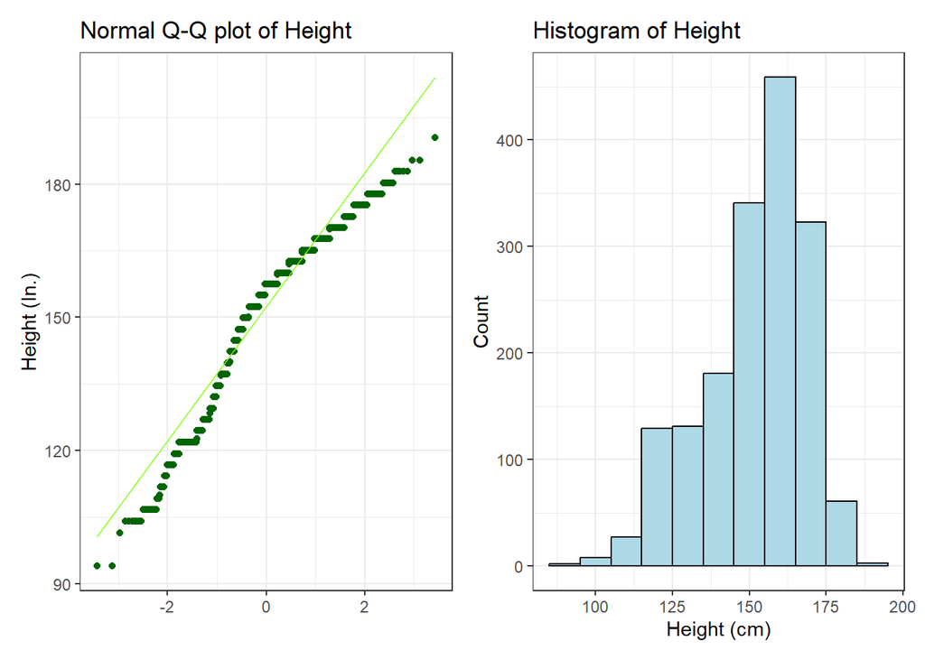

```r
NSCH23_6.2 <- NSCH23 %>% filter(!is.na(height))

p1 <- ggplot(NSCH23_6.2, aes(sample = height)) +
  geom_qq(col = "darkgreen") + geom_qq_line(col = "chartreuse") +
  labs(title = "Normal Q-Q plot of Height", x = "",
       y = "Height (In.)")

p2 <- ggplot(NSCH23_6.2, aes(x = height)) +
  geom_histogram(binwidth = 10, col = "black", fill = "lightblue") +
  labs(title = "Histogram of Height", x = "Height (cm)", y = "Count")

p1 + p2
```

### 6.2.1 Numerical Summary of My Linear Outcome

```r
Hmisc::describe(NSCH23$height)
```

```
NSCH23$height
       n  missing distinct     Info     Mean  pMedian      Gmd      .05
    1665       50       46    0.996    151.9    153.7    17.79    121.9
     .10      .25      .50      .75      .90      .95
   127.0    142.2    157.5    162.6    167.6    172.7

lowest : 93.98  101.49 104.1  106.65 109.21, highest: 177.8  180.31 182.87 185.41 190.5
```

```r
mosaic::favstats(NSCH23$height)
```

```
   min     Q1 median     Q3   max    mean       sd    n missing
 93.98 142.24 157.47 162.56 190.5 151.937 16.20113 1665      50
```

```r
NSCH23 |> tabyl(height) |> adorn_pct_formatting() |>
  arrange(desc(n)) |> head(5)
```

```
 height   n percent valid_percent
 157.47 162    9.4%          9.7%
 160.02 151    8.8%          9.1%
 162.56 143    8.3%          8.6%
 152.40 127    7.4%          7.6%
 165.10 115    6.7%          6.9%
```

157.5 cm is the most common value in my height variable, occurring in 9.4% of my subjects.

```r
sum(!is.na(NSCH23$height))
```

```
[1] 1665
```

There is complete data on 1,665 of the 1,715 subjects’ height values in the NSCH23 tibble.

```r
n_distinct(NSCH23$height)
```

```
[1] 47
```

## 6.3 My Planned Predictors (Linear Model)

My planned predictors for the linear model will be age, meds, severity, sleep, and under_wt.

```r
NSCH23 %>%
  tabyl(severity, sleep, show_na = TRUE) %>%
  adorn_totals(where = c("row", "col"))
```

```
 severity Low Ideal High NA_ Total
     Mild 151   410   90   4   655
 Moderate 231   458  159   7   855
   Severe  48   102   43   1   194
     <NA>   1     7    3   0    11
    Total 431   977  295  12  1715
```

These five predictors are less than the allowed maximum of 4 + (1703-100)/100 = 20.03 ~ 20, out of the 1715 observations in NSCH23 as required by the Project A instructions.

### 6.3.1 Anticipated Direction of Effects

I anticipate that height will have a positive association with meds, severity and sleep. I also anticipate that being positive for low birth weight will point to a lower height at the time of surveying.

### 6.3.2 Missingness Summary

Here is a report on missing data in my predictors for the linear model.

```r
lin_pred <- NSCH23 |> select(age, meds, severity, sleep, under_wt)

miss_var_summary(lin_pred) |> filter(n_miss > 0)
```

```
# A tibble: 4 × 3
  variable n_miss pct_miss
  <chr>     <int>    <num>
1 under_wt     68    3.97
2 sleep        12    0.700
3 severity     11    0.641
4 meds          9    0.525
```

```r
miss_case_table(lin_pred)
```

```
# A tibble: 3 × 3
  n_miss_in_case n_cases pct_cases
           <int>   <int>     <dbl>
1              0    1618    94.3
2              1      94     5.48
3              2       3     0.175
```

I have complete data for all linear model predictors in 1618 (94.3%) of the 1715 rows in my data. I am missing 68 values (4.0%) for under_wt, 12 values (0.7%) for sleep, 11 values (0.64%) for severity, and 9 values for meds (0.53%).

# 7 Logistic Regression Plans

## 7.1 My Second Research Question

How effectively can an anxiety diagnosis be predicted via age, use of ADD/ADHD medication, family structure, divorce, times moved, difficulty making friends, and hours of sleep in female children between the ages of 6-17?

## 7.2 My Binary Outcome

The binary outcome I chose for this question is anxiety, defined as having been previously provided a diagnosis of anxiety by a medical professional. I chose this outcome because anxiety often is a co-occurring condition with ADD/ADHD and, due to this topic of study being relatively new in research, we lack depth in our understanding of this relationship.

```r
NSCH23 |> tabyl(anxiety)
```

```
 anxiety    n     percent valid_percent
     Yes 1044 0.608746356     0.6130358
      No  659 0.384256560     0.3869642
    <NA>   12 0.006997085            NA
```

## 7.3 My Planned Predictors (Logistic Model)

### 7.3.1 Anticipated Direction of Effects

I anticipate that anxiety will occur at a higher frequency as age increases, higher in those who are currently taking medication for ADD/ADHD, higher in those who have less hours of total sleep and have a higher number of moves. I am also anticipating that severe difficulty making friends will be associated with a current diagnosis of anxiety.

### 7.3.2 Missingness Summary

```r
log_pred <- NSCH23 |> select(age, meds, divorce, moves, friends, family)

miss_var_summary(log_pred) |> filter(n_miss > 0)
```

```
# A tibble: 5 × 3
  variable n_miss pct_miss
  <chr>     <int>    <num>
1 divorce      59    3.44
2 family       45    2.62
3 moves        44    2.57
4 friends      12    0.700
5 meds          9    0.525
```

There are a total of 6.6% missing values in my data, with the most occurring in divorce, family and moves, as listed in the next line.

```r
miss_case_table(log_pred)
```

```
# A tibble: 5 × 3
  n_miss_in_case n_cases pct_cases
           <int>   <int>     <dbl>
1              0    1602   93.4
2              1      68    3.97
3              2      35    2.04
4              3       9    0.525
5              4       1    0.0583
```

I have complete data for all of the logistic model predictors in 1602 (93.4%) of the 1715 rows in my data. I am missing 59 values (3.4%) for divorce, 45 values (2.6%) for family, 44 values (2.6%) for moves, 12 values (0.7%) for friends, and 9 values (0.53%)

# 8 Linear Regression Analyses

## 8.1 Missingness

```r
miss_var_summary(NSCH23) |> filter(n_miss > 0)
```

```
# A tibble: 10 × 3
   variable n_miss pct_miss
   <chr>     <int>    <num>
 1 under_wt     68    3.97
 2 divorce      59    3.44
 3 height       50    2.92
 4 family       45    2.62
 5 moves        44    2.57
 6 anxiety      12    0.700
 7 sleep        12    0.700
 8 friends      12    0.700
 9 severity     11    0.641
10 meds          9    0.525
```

While missingness is relatively low in this data, I will be assuming they are missing at random and am performing a single imputation as a result. I chose to perform a single imputation because of my low (6.6%) missingness in the data and due to the assumption of MAR.

```r
NSCH23_SI <-
  mice(NSCH23, m = 1, seed = 4322025, print = FALSE) |>
  complete() |>
  tibble()
```

```r
n_miss(NSCH23_SI)
```

```
[1] 0
```

## 8.2 Outcome Transformation

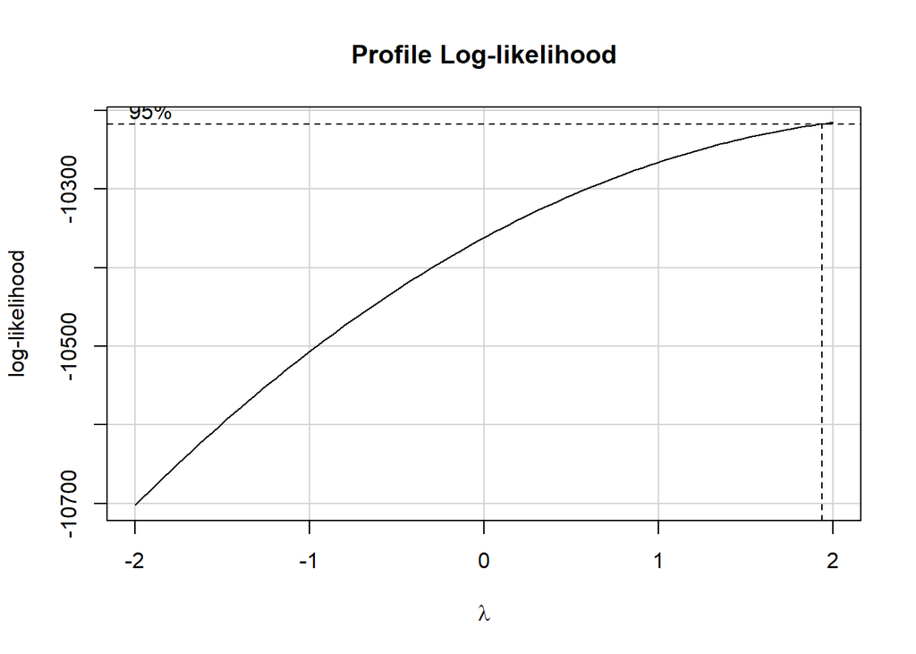

```r
NSCH23_T <- lm(height ~ age + meds + severity + sleep + under_wt, data = NSCH23_SI)

#| fig-height: 12
#| fig-width: 12

boxCox(NSCH23_T)
```

According to the above plot, the Box-Cox approach would suggest that I transform the data by squaring the height variable.

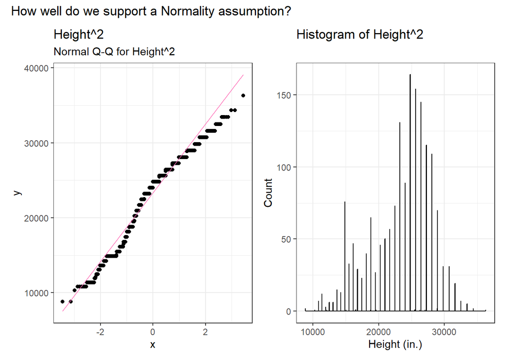

```r
p1 <- ggplot(NSCH23_SI, aes(sample = height^2)) +
  geom_qq() + geom_qq_line(col = "hotpink") +
  labs(title = "Height^2",
       subtitle = "Normal Q-Q for Height^2")

p2 <- ggplot(NSCH23_SI, aes(x = height^2)) +
  geom_histogram(binwidth = 10, col = "black", fill = "blue") +
  labs(title = "Histogram of Height^2", x = "Height (in.)", y = "Count")

p1 + p2 +
  plot_annotation("How well do we support a Normality assumption?")
```

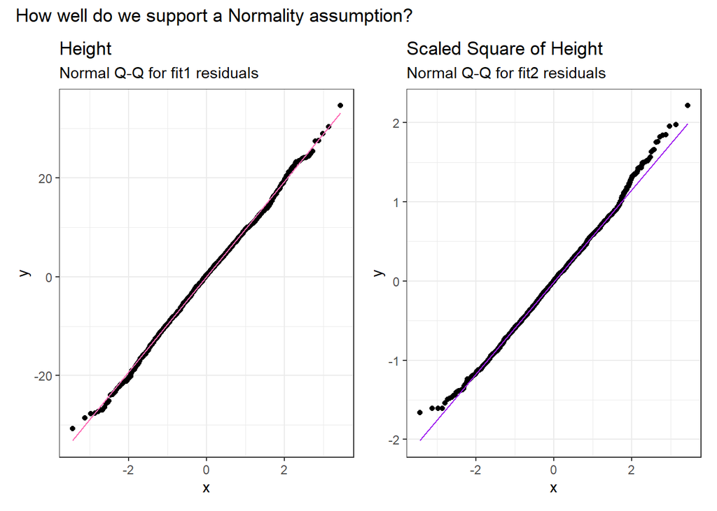

```r
NSCH23_Sq <- lm(scale(height^2, center = TRUE, scale = TRUE) ~
             age + meds+ severity+ sleep+ under_wt, data = NSCH23_SI)

resids_NSCH23 <- tibble(raw = NSCH23_T$residuals,
                 sqr = NSCH23_Sq$residuals)

p1 <- ggplot(resids_NSCH23, aes(sample = raw)) +
  geom_qq() + geom_qq_line(col = "hotpink") +
  labs(title = "Height",
       subtitle = "Normal Q-Q for fit1 residuals")

p2 <- ggplot(resids_NSCH23, aes(sample = sqr)) +
  geom_qq() + geom_qq_line(col = "purple") +
  labs(title = "Scaled Square of Height",
       subtitle = "Normal Q-Q for fit2 residuals")

p1 + p2 +
  plot_annotation("How well do we support a Normality assumption?")
```

There is still a decrease in normality, even after scaling my squared outcome. Because of this, I will not be proceeding with a transformed outcome, and will instead be proceeding with my original height data for the rest of the project.

## 8.3 Scatterplot Matrix and Collinearity

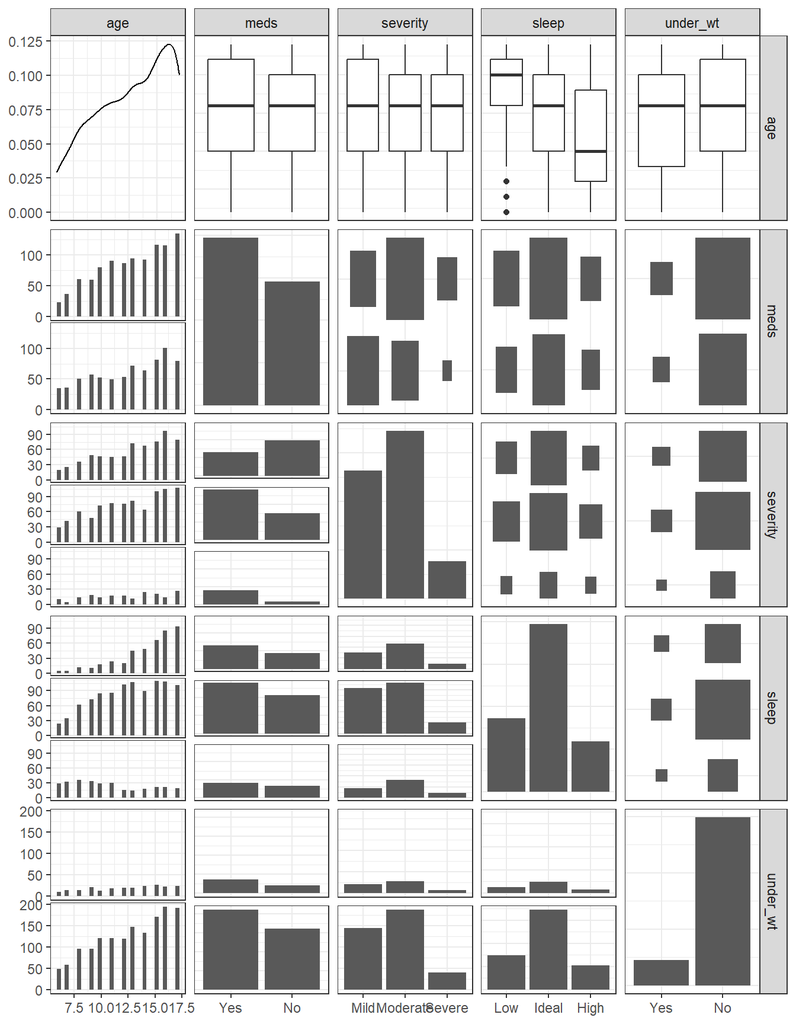

```r
ggpairs(NSCH23_SI, columns = c("age","meds","severity","sleep","under_wt"))
```

```r
mA <- lm(height ~ age + meds + severity + sleep + under_wt, data = NSCH23_SI)

car::vif(mA)
```

```
             GVIF Df GVIF^(1/(2*Df))
age      1.147204  1        1.071076
meds     1.106075  1        1.051701
severity 1.115637  2        1.027734
sleep    1.152177  2        1.036048
under_wt 1.006823  1        1.003406
```

There are no obvious issues with multicollinearity, so no adjustments are needed.

## 8.4 Model A

### 8.4.1 Fitting Model A

```r
mA <- lm(height ~ age + meds + severity + sleep + under_wt, data = NSCH23_SI)
```

```r
dd <- datadist(NSCH23_SI)
options(datadist = "dd")

mA_OLS <- ols(height ~ age + meds + severity + sleep + under_wt, data = NSCH23_SI, x = TRUE, y = TRUE)
```

### 8.4.2 Coefficient Estimates

```r
model_parameters(mA, ci = 0.90) |> print_md(digits = 3)
```

| Parameter | Coefficient | SE | 90% CI | t(1707) | p |
| --- | --- | --- | --- | --- | --- |
| (Intercept) | 98.731 | 1.386 | (96.451, 101.011) | 71.260 | < .001 |
| age | 3.964 | 0.077 | (3.837, 4.090) | 51.605 | < .001 |
| meds (No) | -0.902 | 0.495 | (-1.716, -0.088) | -1.824 | 0.068 |
| severity (Moderate) | -0.625 | 0.517 | (-1.476, 0.226) | -1.208 | 0.227 |
| severity (Severe) | -1.842 | 0.817 | (-3.186, -0.498) | -2.256 | 0.024 |
| sleep (Ideal) | 0.589 | 0.572 | (-0.353, 1.531) | 1.030 | 0.303 |
| sleep (High) | -0.984 | 0.773 | (-2.255, 0.288) | -1.273 | 0.203 |
| under wt (No) | 4.082 | 0.692 | (2.943, 5.221) | 5.898 | < .001 |

### 8.4.3 Model A Effects

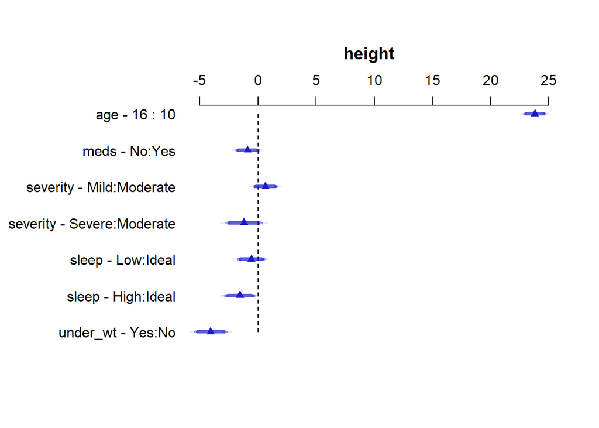

```r
plot(summary(mA_OLS, conf.int = 0.90))
```

```r
summary(mA_OLS, conf.int = 0.90) |> kable(digits=3)
```

|  | Low | High | Diff. | Effect | S.E. | Lower 0.9 | Upper 0.9 | Type |
| --- | --- | --- | --- | --- | --- | --- | --- | --- |
| age | 10 | 16 | 6 | 23.783 | 0.461 | 23.025 | 24.541 | 1 |
| meds - No:Yes | 1 | 2 | NA | -0.902 | 0.495 | -1.716 | -0.088 | 1 |
| severity - Mild:Moderate | 2 | 1 | NA | 0.625 | 0.517 | -0.226 | 1.476 | 1 |
| severity - Severe:Moderate | 2 | 3 | NA | -1.217 | 0.769 | -2.483 | 0.049 | 1 |
| sleep - Low:Ideal | 2 | 1 | NA | -0.589 | 0.572 | -1.531 | 0.353 | 1 |
| sleep - High:Ideal | 2 | 3 | NA | -1.573 | 0.653 | -2.648 | -0.498 | 1 |
| under_wt - Yes:No | 2 | 1 | NA | -4.082 | 0.692 | -5.221 | -2.943 | 1 |

### 8.4.4 Quality of Fit Summaries

```r
model_performance(mA) |> print_md(digits = 3)
```

Indices of model performance

| AIC | AICc | BIC | R2 | R2 (adj.) | RMSE | Sigma |
| --- | --- | --- | --- | --- | --- | --- |
| 12644.087 | 12644.193 | 12693.112 | 0.652 | 0.651 | 9.604 | 9.626 |

```r
glance(mA) |>
  select(r2 = r.squared, adjr2 = adj.r.squared, sigma,
         AIC, BIC, nobs, df, df.residual) |>
  kable(digits = c(3, 3, 2, 1, 1, 0, 0, 0))
```

| r2 | adjr2 | sigma | AIC | BIC | nobs | df | df.residual |
| --- | --- | --- | --- | --- | --- | --- | --- |
| 0.652 | 0.651 | 9.63 | 12644.1 | 12693.1 | 1715 | 7 | 1707 |

### 8.4.5 Regression Diagnostics (Model A)

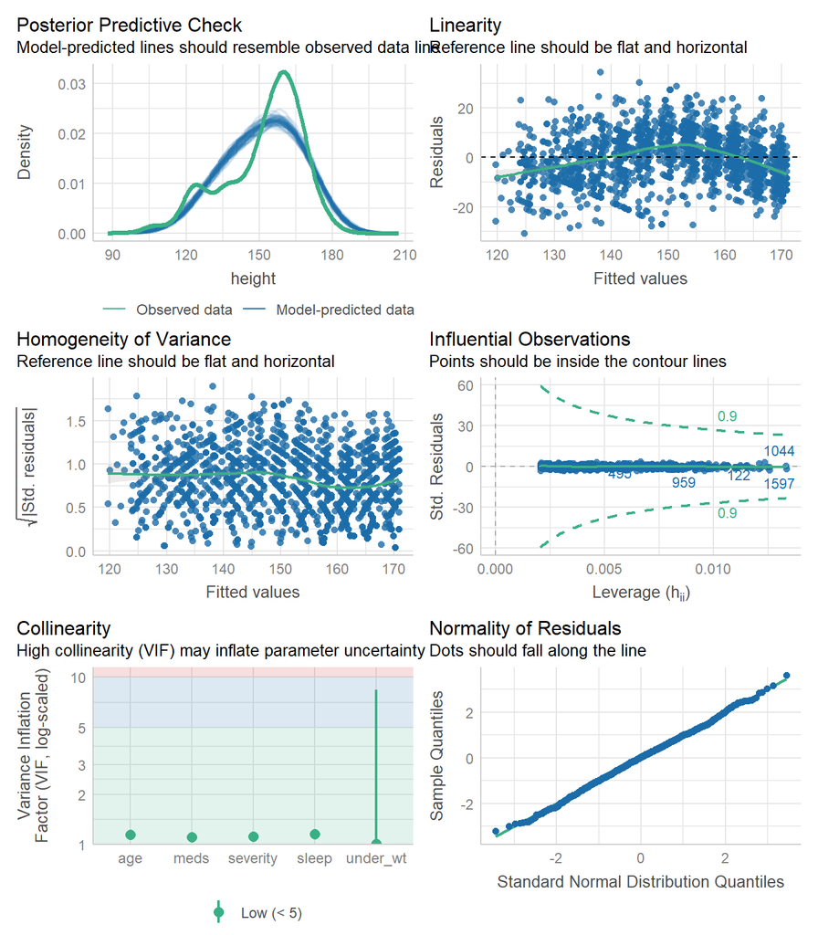

```r
check_model(mA, detrend = FALSE)
```

## 8.5 Non-Linearity and Spearman $\rho^2$

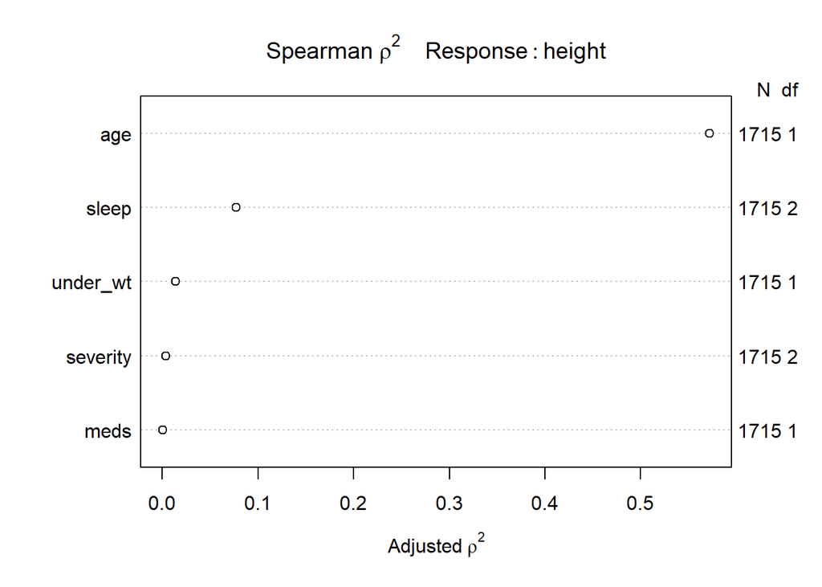

```r
plot(spearman2(height ~ age + meds+ severity+ sleep+ under_wt, data = NSCH23_SI))
```

## 8.6 Model B

### 8.6.1 Fitting Model B

```r
mB <- lm(height ~ rcs(age, 4) + meds + severity + sleep + age %ia% sleep + under_wt, data = NSCH23_SI)
```

```r
dd <- datadist(NSCH23_SI)
options(datadist = "dd")

mB_OLS <- ols(height ~ rcs(age, 4) + meds + severity + sleep + age %ia% sleep + under_wt, data = NSCH23_SI, x = TRUE, y = TRUE)
```

```r
anova(mB)
```

```
Analysis of Variance Table

Response: height
                 Df Sum Sq Mean Sq   F value    Pr(>F)
rcs(age, 4)       3 315679  105226 1325.3255 < 2.2e-16 ***
meds              1     10      10    0.1280    0.7206
severity          2    421     210    2.6506    0.0709 .
sleep             2      6       3    0.0348    0.9658
age %ia% sleep    2     36      18    0.2261    0.7977
under_wt          1   3233    3233   40.7155 2.264e-10 ***
Residuals      1703 135213      79
---
Signif. codes:  0 '***' 0.001 '**' 0.01 '*' 0.05 '.' 0.1 ' ' 1
```

### 8.6.2 Coefficient Estimates

```r
tidy(mB, conf.int = TRUE, conf.level = 0.90) |>
  select(term, estimate, se = std.error,
         low90 = conf.low, high90 = conf.high,
         p = p.value) |>
  kable(digits = 3)
```

| term | estimate | se | low90 | high90 | p |
| --- | --- | --- | --- | --- | --- |
| (Intercept) | 78.057 | 3.541 | 72.229 | 83.884 | 0.000 |
| rcs(age, 4)age | 6.212 | 0.339 | 5.654 | 6.771 | 0.000 |
| rcs(age, 4)age’ | -1.783 | 0.686 | -2.911 | -0.654 | 0.009 |
| rcs(age, 4)age’’ | -3.237 | 2.358 | -7.117 | 0.644 | 0.170 |
| medsNo | -0.562 | 0.459 | -1.317 | 0.194 | 0.221 |
| severityModerate | -0.527 | 0.480 | -1.316 | 0.263 | 0.272 |
| severitySevere | -1.662 | 0.756 | -2.907 | -0.418 | 0.028 |
| sleepIdeal | 0.265 | 2.652 | -4.099 | 4.630 | 0.920 |
| sleepHigh | -1.305 | 3.003 | -6.247 | 3.636 | 0.664 |
| age %ia% sleepage * sleep=Ideal | -0.032 | 0.189 | -0.342 | 0.279 | 0.867 |
| age %ia% sleepage * sleep=High | 0.090 | 0.230 | -0.288 | 0.468 | 0.695 |
| under_wtNo | 4.092 | 0.641 | 3.037 | 5.148 | 0.000 |

### 8.6.3 Model B Effects

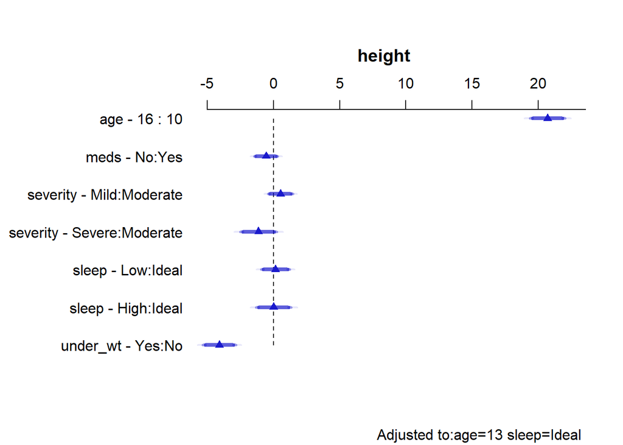

```r
plot(summary(mB_OLS, conf.int = 0.90))
```

### 8.6.4 Quality of Fit Summaries

```r
summary(mB_OLS, conf.int = 0.90) |> kable(digits = 3)
```

|  | Low | High | Diff. | Effect | S.E. | Lower 0.9 | Upper 0.9 | Type |
| --- | --- | --- | --- | --- | --- | --- | --- | --- |
| age | 10 | 16 | 6 | 20.709 | 0.677 | 19.595 | 21.824 | 1 |
| meds - No:Yes | 1 | 2 | NA | -0.562 | 0.459 | -1.317 | 0.194 | 1 |
| severity - Mild:Moderate | 2 | 1 | NA | 0.527 | 0.480 | -0.263 | 1.316 | 1 |
| severity - Severe:Moderate | 2 | 3 | NA | -1.136 | 0.713 | -2.309 | 0.037 | 1 |
| sleep - Low:Ideal | 2 | 1 | NA | 0.145 | 0.554 | -0.767 | 1.057 | 1 |
| sleep - High:Ideal | 2 | 3 | NA | 0.011 | 0.685 | -1.116 | 1.138 | 1 |
| under_wt - Yes:No | 2 | 1 | NA | -4.092 | 0.641 | -5.148 | -3.037 | 1 |

```r
model_performance(mB)
```

```
# Indices of model performance

AIC       |      AICc |       BIC |    R2 | R2 (adj.) |  RMSE | Sigma
---------------------------------------------------------------------
12383.110 | 12383.324 | 12453.923 | 0.703 |     0.701 | 8.879 | 8.910
```

```r
glance(mB) |>
  select(r2 = r.squared, adjr2 = adj.r.squared, sigma,
         AIC, BIC, nobs, df, df.residual) |>
  kable(digits = c(3, 3, 2, 1, 1, 0, 0, 0))
```

| r2 | adjr2 | sigma | AIC | BIC | nobs | df | df.residual |
| --- | --- | --- | --- | --- | --- | --- | --- |
| 0.703 | 0.701 | 8.91 | 12383.1 | 12453.9 | 1715 | 11 | 1703 |

### 8.6.5 Regression Diagnostics (Model B)

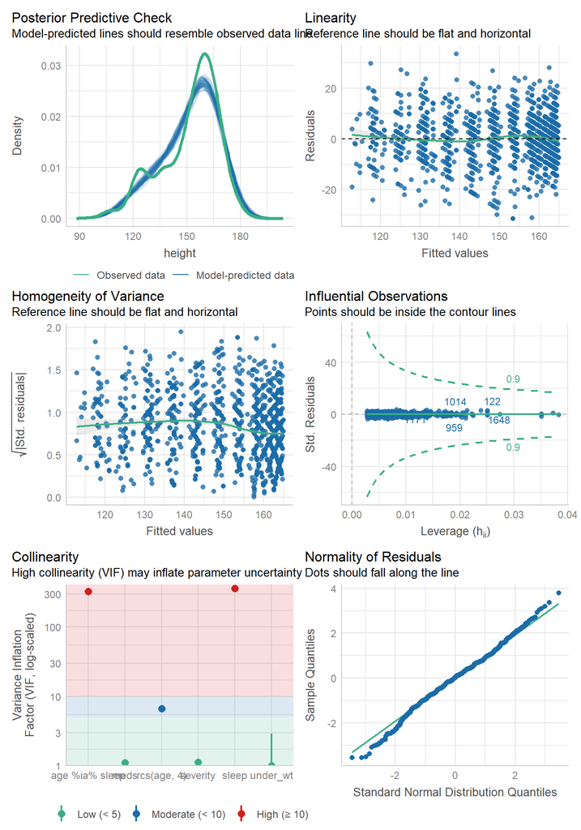

```r
check_model(mB, detrend = FALSE)
```

Model B shows some variation between the observed and predicted data in the posterior predictive check, but this is a much closer fit than was seen in the same plot for model A. The reference line for linearity stays relatively flat throughout the plot, with mild deviation on the left tail. There is slight homoscedasticity evidenced in the variance plot, with a mild downward curve on the right tail, but this does not appear to majorly violate the variance assumption. There seems to be no issue with influential observations. There is also clear uptick in collinearity, but this is due to the interaction term introduced in building model B. Lastly, normality shows some deviation in the left and right tails, suggesting mild violation of the normality assumption.

## 8.7 Validating Models A and B

```r
set.seed(4321); (validA <- validate(mA_OLS))
```

```
          index.orig training    test optimism index.corrected  n
R-square      0.6521   0.6507  0.6504   0.0003          0.6517 40
MSE          92.2288  92.8389 92.6763   0.1625         92.0663 40
g            15.0322  15.0358 15.0179   0.0180         15.0142 40
Intercept     0.0000   0.0000  0.0064  -0.0064          0.0064 40
Slope         1.0000   1.0000  0.9999   0.0001          0.9999 40
```

```r
set.seed(4321); (validB <- validate(mB_OLS))
```

```
          index.orig training    test optimism index.corrected  n
R-square      0.7026   0.7029  0.7004   0.0025          0.7001 40
MSE          78.8411  78.9679 79.4053  -0.4375         79.2786 40
g            14.5968  14.6254 14.5831   0.0423         14.5545 40
Intercept     0.0000   0.0000  0.1066  -0.1066          0.1066 40
Slope         1.0000   1.0000  0.9992   0.0008          0.9992 40
```

### 8.7.1 Validated $R^2$, and MSE as well as IC statistics

| Model | Validated $R^2$ | Validated MSE | AIC | BIC | df |
| --- | --- | --- | --- | --- | --- |
| A | 0.652 | 92.0663 | 12644.1 | 12693.1 | 7 |
| B | 0.700 | 79.279 | 12383.1 | 12453.9 | 11 |

## 8.8 Final Linear Regression Model

I prefer Model B, because of its validated R2, MSE, AIC, and BIC values being superior to those of model A. Model B also showed much better alignment with the assumption of linearity, and a closer fit between observed and predicted data in the posterior predictive check than model A. While model B’s performance is lacking in some areas, its performance here was overall more impressive than model A.

### 8.8.1 Winning Model’s OLS Summary

```r
mB_OLS
```

```
Linear Regression Model

ols(formula = height ~ rcs(age, 4) + meds + severity + sleep +
    age %ia% sleep + under_wt, data = NSCH23_SI, x = TRUE, y = TRUE)

                 Model Likelihood    Discrimination
                       Ratio Test           Indexes
Obs    1715    LR chi2    2079.55    R2       0.703
sigma8.9105    d.f.            11    R2 adj   0.701
d.f.   1703    Pr(> chi2)  0.0000    g       14.597

Residuals

     Min       1Q   Median       3Q      Max
-31.4276  -5.7321   0.3343   5.8441  33.6335

                  Coef    S.E.   t     Pr(>|t|)
Intercept         78.0567 3.5408 22.04 <0.0001
age                6.2123 0.3394 18.31 <0.0001
age'              -1.7829 0.6857 -2.60 0.0094
age''             -3.2365 2.3578 -1.37 0.1700
meds=No           -0.5616 0.4590 -1.22 0.2213
severity=Moderate -0.5266 0.4796 -1.10 0.2724
severity=Severe   -1.6624 0.7560 -2.20 0.0280
sleep=Ideal        0.2653 2.6521  0.10 0.9203
sleep=High        -1.3054 3.0028 -0.43 0.6638
age * sleep=Ideal -0.0316 0.1887 -0.17 0.8672
age * sleep=High   0.0901 0.2296  0.39 0.6948
under_wt=No        4.0923 0.6413  6.38 <0.0001
```

### 8.8.2 Effects Plot for Winning Model

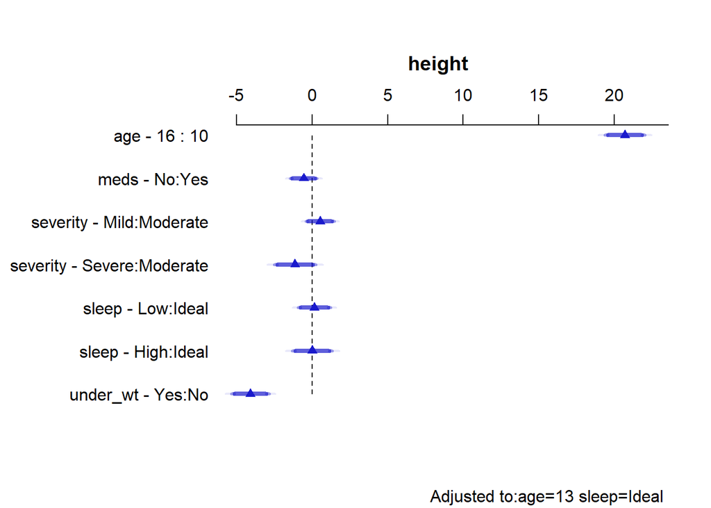

```r
plot(summary(mB_OLS, conf.int = 0.90))
```

Here, the first biggest takeaway is that height is shown to have a strong and positive association with age, which intuitively makes sense. Next, meds and severity have a mild, negative association with height, and birth weight status seems to have a stronger negative effect on height.

### 8.8.3 Numerical Description of Effect Sizes

```r
summary(mB_OLS, conf.int = 0.90) |> kable(digits = 3)
```

|  | Low | High | Diff. | Effect | S.E. | Lower 0.9 | Upper 0.9 | Type |
| --- | --- | --- | --- | --- | --- | --- | --- | --- |
| age | 10 | 16 | 6 | 20.709 | 0.677 | 19.595 | 21.824 | 1 |
| meds - No:Yes | 1 | 2 | NA | -0.562 | 0.459 | -1.317 | 0.194 | 1 |
| severity - Mild:Moderate | 2 | 1 | NA | 0.527 | 0.480 | -0.263 | 1.316 | 1 |
| severity - Severe:Moderate | 2 | 3 | NA | -1.136 | 0.713 | -2.309 | 0.037 | 1 |
| sleep - Low:Ideal | 2 | 1 | NA | 0.145 | 0.554 | -0.767 | 1.057 | 1 |
| sleep - High:Ideal | 2 | 3 | NA | 0.011 | 0.685 | -1.116 | 1.138 | 1 |
| under_wt - Yes:No | 2 | 1 | NA | -4.092 | 0.641 | -5.148 | -3.037 | 1 |

The shown effect sizes for model B are after trying a few combinations of non-linear terms or lack thereof. After fitting the model a few different ways, I ended with the current combination, due to its having the least explosive effects on my predictors’ effects.

### 8.8.4 Effect Size Description

Description of severity (ADD/ADHD): Let’s say there are two subjects that have equal age, medication use, sleep, and underweight status, named Ginny and Lilly. If Ginny has severe ADD/ADHD, but Lilly has moderate ADD/ADHD, my model estimates that Ginny’s height will be 1.14 cm lower than Lilly’s, with a 90% confidence interval of (-2.31, 0.04) cm.

Description of birth weight status: Let’s use the same two subjects as above, Ginny and Lilly, and assume equal age, medication use, severity, and sleep between them. If Ginny had was underweight at birth, but Lilly was not, my model estimates that Ginny’s height will be 4.09 cm lower than Lilly’s, with a 90% confidence interval of (-5.15, -3.04) cm.

### 8.8.5 Prediction Plot for Winning Model

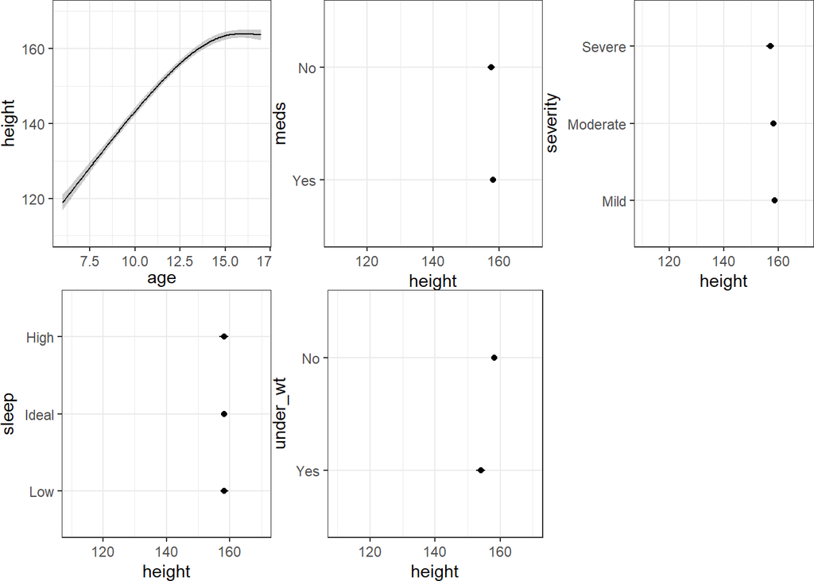

```r
ggplot(Predict(mB_OLS))
```

### 8.8.6 Nomogram of Winning Model

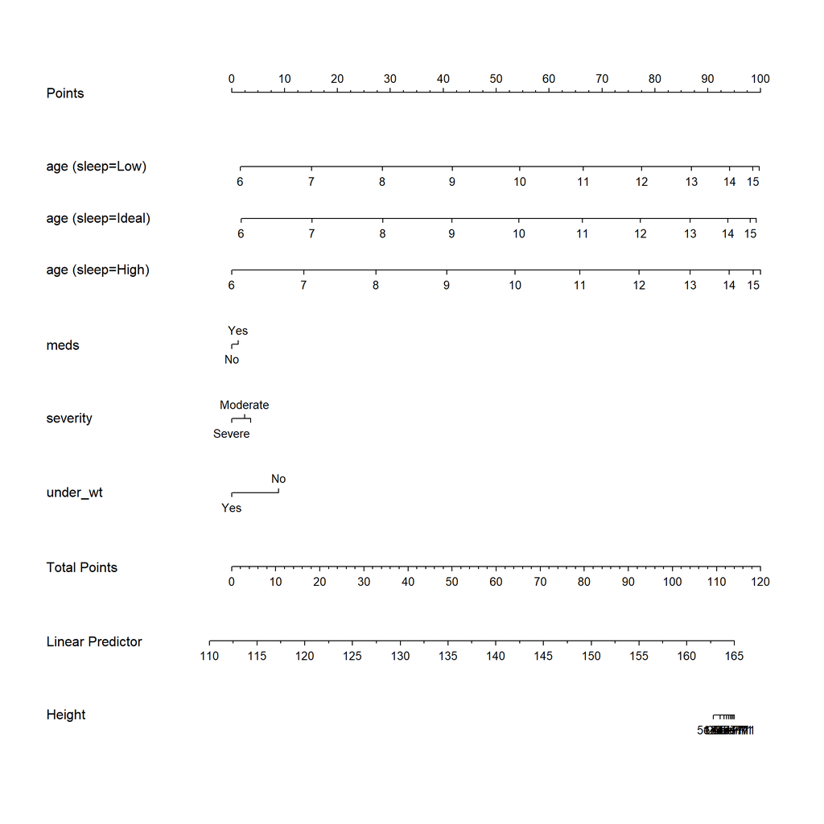

```r
plot(nomogram(mB_OLS, fun = exp, funlabel = "Height"))
```

### 8.8.7 Prediction for a New Subject

```r
new_subject <- data.frame(
  age = c(10, 10),
  meds = factor(c("Yes", "No"), levels = c("Yes", "No")),
  anxiety = factor(c("No", "No"), levels = c("Yes", "No")),
  sleep = factor(c("Ideal", "Ideal"), levels = c("Low", "Ideal", "High")),
  severity = factor(c("Severe", "Severe"), levels = c("Mild", "Moderate", "Severe")),
  under_wt = factor(c("No", "No"), levels = c("Yes", "No")))

pred_mB <- predict.lm(mB, newdata = new_subject, interval = "prediction", level = 0.90)

pred_mB
```

```
       fit      lwr      upr
1 142.0780 127.3592 156.7968
2 141.5164 126.7848 156.2481
```

I wanted to conclude my findings on model B by exploring the effect of meds on height a bit more, as it has consistently taken up the least space in my estimates, plots, and the nomogram generated for this model. Here, I am predicting the heights of two subjects whom I will call Nelly and Samantha. Both are the age of 10, have not been diagnosed with anxiety by a medical professional, get an ideal average amount of sleep per week, have severe ADD/ADHD, and were not underweight at birth. However, Nelly currently takes medication for her severe ADD/ADHD, while Samantha does not. According to the predictions of my model, Nelly would have a height of 142.1 cm, while Samantha’s height would be 141.5 cm.

| **Predictor Values** | **Predicted Height** | **90% Prediction Interval** |
| --- | --- | --- |
| age = 10, meds = Yes, anxiety = No, sleep = Ideal, severity = Severe, under_wt = No | 142.1 | (127.4, 156.8) cm |
| age = 10, meds = No, anxiety = No, sleep = Ideal, severity = Severe, under_wt = No | 141.5 | (126.8, 156.3) cm |

# 9 Logistic Regression Analyses

## 9.1 Missingness

```r
miss_var_summary(NSCH23_SI) |> filter(n_miss > 0)
```

```
# A tibble: 0 × 3
# ℹ 3 variables: variable <chr>, n_miss <int>, pct_miss <num>
```

## 9.2 Model Y

### 9.2.1 Fitting Model Y

```r
mY <- glm(anxiety ~ age + moves +  meds +  divorce +  friends +  family,
            data = NSCH23_SI, family = binomial())

summary(NSCH23_SI$anxiety)
```

```
 Yes   No
1052  663
```

```r
ddd <- datadist(NSCH23_SI)
options(datadist = "ddd")

mY_lrm <- lrm(anxiety ~ age +  meds +  divorce +  moves +  friends +  family,
                 data = NSCH23_SI, x = TRUE, y = TRUE)
```

### 9.2.2 Coefficient Estimates

```r
tidy(mY, exponentiate = TRUE, conf.int = TRUE, conf.level = 0.90) |>
  select(term, estimate, se = std.error,
         low90 = conf.low, high90 = conf.high, p = p.value) |>
  kable(digits = 3)
```

| term | estimate | se | low90 | high90 | p |
| --- | --- | --- | --- | --- | --- |
| (Intercept) | 2.017 | 0.265 | 1.304 | 3.123 | 0.008 |
| age | 0.869 | 0.016 | 0.845 | 0.892 | 0.000 |
| moves | 0.966 | 0.026 | 0.926 | 1.007 | 0.175 |
| medsNo | 1.148 | 0.107 | 0.963 | 1.369 | 0.197 |
| divorceNo | 1.428 | 0.139 | 1.137 | 1.796 | 0.010 |
| friendsNone | 2.503 | 0.106 | 2.103 | 2.981 | 0.000 |
| familyUnmarried | 0.960 | 0.250 | 0.633 | 1.445 | 0.870 |
| familySingle | 0.849 | 0.148 | 0.666 | 1.082 | 0.269 |
| familyOther | 1.438 | 0.230 | 0.983 | 2.097 | 0.114 |

### 9.2.3 Model Y Effects

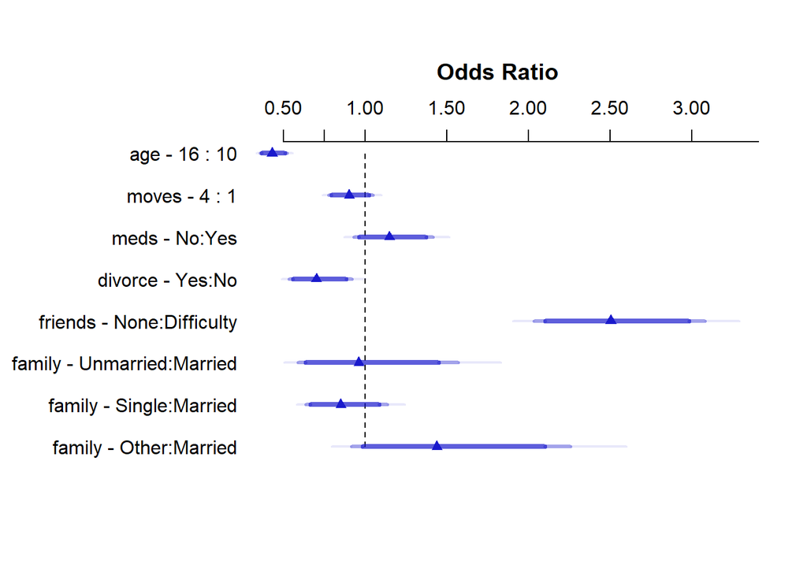

```r
plot(summary(mY_lrm, conf.int = 0.90))
```

```r
summary(mY_lrm, conf.int = 0.90) |> kable(digits = 3)
```

|  | Low | High | Diff. | Effect | S.E. | Lower 0.9 | Upper 0.9 | Type |
| --- | --- | --- | --- | --- | --- | --- | --- | --- |
| age | 10 | 16 | 6 | -0.845 | 0.098 | -1.007 | -0.683 | 1 |
| Odds Ratio | 10 | 16 | 6 | 0.430 | NA | 0.365 | 0.505 | 2 |
| moves | 1 | 4 | 3 | -0.104 | 0.077 | -0.231 | 0.022 | 1 |
| Odds Ratio | 1 | 4 | 3 | 0.901 | NA | 0.794 | 1.023 | 2 |
| meds - No:Yes | 1 | 2 | NA | 0.138 | 0.107 | -0.038 | 0.314 | 1 |
| Odds Ratio | 1 | 2 | NA | 1.148 | NA | 0.963 | 1.369 | 2 |
| divorce - Yes:No | 2 | 1 | NA | -0.356 | 0.139 | -0.585 | -0.128 | 1 |
| Odds Ratio | 2 | 1 | NA | 0.700 | NA | 0.557 | 0.880 | 2 |
| friends - None:Difficulty | 1 | 2 | NA | 0.917 | 0.106 | 0.743 | 1.092 | 1 |
| Odds Ratio | 1 | 2 | NA | 2.503 | NA | 2.102 | 2.979 | 2 |
| family - Unmarried:Married | 1 | 2 | NA | -0.041 | 0.250 | -0.453 | 0.371 | 1 |
| Odds Ratio | 1 | 2 | NA | 0.960 | NA | 0.636 | 1.449 | 2 |
| family - Single:Married | 1 | 3 | NA | -0.163 | 0.148 | -0.406 | 0.079 | 1 |
| Odds Ratio | 1 | 3 | NA | 0.849 | NA | 0.666 | 1.083 | 2 |
| family - Other:Married | 1 | 4 | NA | 0.363 | 0.230 | -0.015 | 0.741 | 1 |
| Odds Ratio | 1 | 4 | NA | 1.438 | NA | 0.985 | 2.098 | 2 |

### 9.2.4 Quality of Fit Summaries

```r
mY_lrm
```

```
Logistic Regression Model

lrm(formula = anxiety ~ age + meds + divorce + moves + friends +
    family, data = NSCH23_SI, x = TRUE, y = TRUE)

                       Model Likelihood       Discrimination    Rank Discrim.
                             Ratio Test              Indexes          Indexes
Obs          1715    LR chi2     197.53       R2       0.148    C       0.697
 Yes         1052    d.f.             8      R2(8,1715)0.105    Dxy     0.395
 No           663    Pr(> chi2) <0.0001    R2(8,1220.1)0.144    gamma   0.395
max |deriv| 5e-09                             Brier    0.211    tau-a   0.187

                 Coef    S.E.   Wald Z Pr(>|Z|)
Intercept         0.7014 0.2654  2.64  0.0082
age              -0.1408 0.0164 -8.58  <0.0001
meds=No           0.1380 0.1070  1.29  0.1969
divorce=No        0.3564 0.1388  2.57  0.0102
moves            -0.0348 0.0257 -1.36  0.1754
friends=None      0.9173 0.1060  8.65  <0.0001
family=Unmarried -0.0411 0.2503 -0.16  0.8696
family=Single    -0.1632 0.1475 -1.11  0.2685
family=Other      0.3629 0.2299  1.58  0.1145
```

```r
glance(mY) |>
  mutate(df = nobs - df.residual - 1) |>
  select(AIC, BIC, df, df.residual, nobs) |>
  kable(digits = 1)
```

| AIC | BIC | df | df.residual | nobs |
| --- | --- | --- | --- | --- |
| 2109 | 2158 | 8 | 1706 | 1715 |

### 9.2.5 Confusion Matrix (Model Y)

```r
resY_aug <- augment(mY, type.predict = "response")
```

My prediction rule for this confusion matrix is that the fitted value of Pr(anxiety = Yes) needs to be greater than or equal to 0.5 for me to predict anxiety as 1. If it is not, I will instead predict 0.

```r
cm_Y <- caret::confusionMatrix(
  data = factor(resY_aug$.fitted >= 0.5),
  reference = factor(resY_aug$anxiety == "Yes"),
  positive = "TRUE")

cm_Y
```

```
Confusion Matrix and Statistics

          Reference
Prediction FALSE TRUE
     FALSE   401  885
     TRUE    262  167

               Accuracy : 0.3312
                 95% CI : (0.3089, 0.354)
    No Information Rate : 0.6134
    P-Value [Acc > NIR] : 1

                  Kappa : -0.2014

 Mcnemar's Test P-Value : <2e-16

            Sensitivity : 0.15875
            Specificity : 0.60483
         Pos Pred Value : 0.38928
         Neg Pred Value : 0.31182
             Prevalence : 0.61341
         Detection Rate : 0.09738
   Detection Prevalence : 0.25015
      Balanced Accuracy : 0.38179

       'Positive' Class : TRUE
```

## 9.3 Non-Linearity and Spearman $\rho^2$ Plot

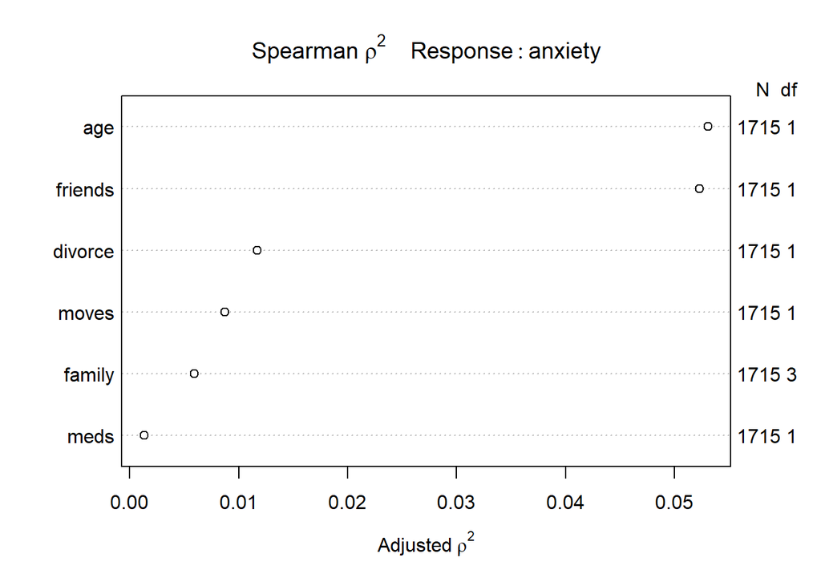

```r
plot(spearman2(anxiety ~ age +  meds +  divorce +  moves +  friends +  family,
               data = NSCH23_SI))
```

## 9.4 Model Z

### 9.4.1 Fitting Model Z

```r
mZ <- glm(anxiety ~ rcs(age, 4) + meds + divorce + moves + friends +
            age %ia% friends + family,
          data = NSCH23_SI, family = binomial())


ddd <- datadist(NSCH23_SI)
options(datadist = "ddd")

mZ_lrm <- lrm(anxiety ~ rcs(age, 4) + meds + divorce + moves + friends +
                age %ia% friends + family,
              data = NSCH23_SI, x = TRUE, y = TRUE)
```

```r
anova(mZ)
```

```
Analysis of Deviance Table

Model: binomial, link: logit

Response: anxiety

Terms added sequentially (first to last)

                 Df Deviance Resid. Df Resid. Dev  Pr(>Chi)
NULL                              1714     2288.5
rcs(age, 4)       3   94.770      1711     2193.7 < 2.2e-16 ***
meds              1    1.749      1710     2192.0   0.18595
divorce           1   18.249      1709     2173.7 1.939e-05 ***
moves             1    3.262      1708     2170.5   0.07089 .
friends           1   77.565      1707     2092.9 < 2.2e-16 ***
age %ia% friends  1    1.699      1706     2091.2   0.19244
family            3    4.624      1703     2086.6   0.20151
---
Signif. codes:  0 '***' 0.001 '**' 0.01 '*' 0.05 '.' 0.1 ' ' 1
```

### 9.4.2 Tidied Odds Ratio Estimates (Model Z)

```r
tidy(mZ, exponentiate = TRUE, conf.int = TRUE, conf.level = 0.90) |>
  select(term, estimate, se = std.error,
         low90 = conf.low, high90 = conf.high, p = p.value) |>
  kable(digits = 3)
```

| term | estimate | se | low90 | high90 | p |
| --- | --- | --- | --- | --- | --- |
| (Intercept) | 3.570 | 0.630 | 1.271 | 10.099 | 0.043 |
| rcs(age, 4)age | 0.812 | 0.068 | 0.726 | 0.908 | 0.002 |
| rcs(age, 4)age’ | 1.231 | 0.163 | 0.942 | 1.610 | 0.203 |
| rcs(age, 4)age’’ | 0.411 | 0.577 | 0.159 | 1.059 | 0.123 |
| medsNo | 1.147 | 0.107 | 0.961 | 1.369 | 0.201 |
| divorceNo | 1.433 | 0.139 | 1.141 | 1.803 | 0.010 |
| moves | 0.965 | 0.026 | 0.925 | 1.007 | 0.171 |
| friendsNone | 1.566 | 0.423 | 0.782 | 3.149 | 0.289 |
| age %ia% friends | 1.040 | 0.033 | 0.985 | 1.098 | 0.238 |
| familyUnmarried | 0.964 | 0.250 | 0.636 | 1.450 | 0.882 |
| familySingle | 0.855 | 0.148 | 0.670 | 1.089 | 0.288 |
| familyOther | 1.416 | 0.231 | 0.967 | 2.068 | 0.132 |

### 9.4.3 Model Z Effects

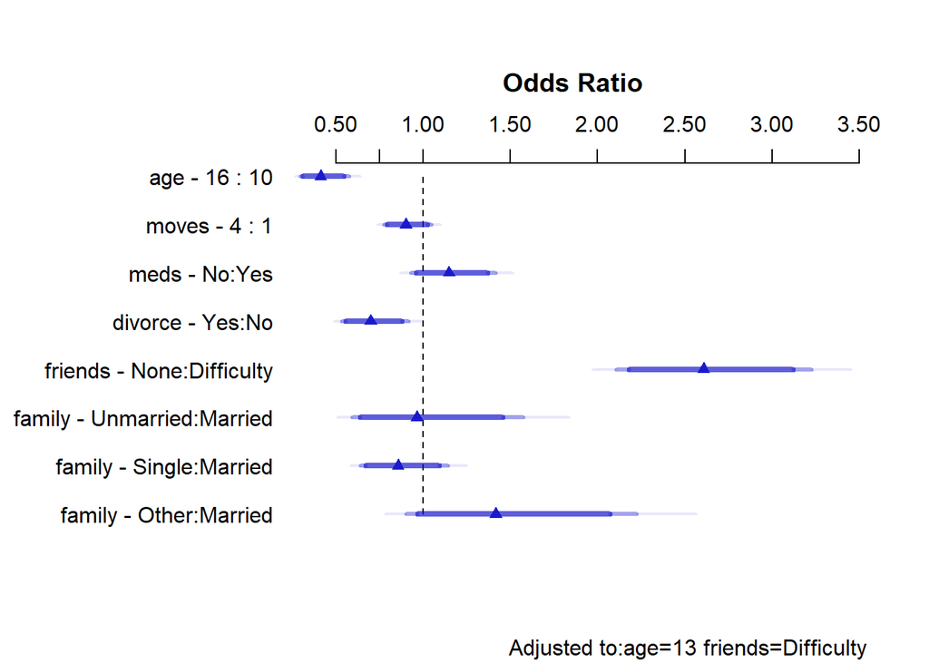

```r
plot(summary(mZ_lrm, conf.int = 0.90))
```

```r
summary(mZ_lrm, conf.int = 0.90) |> kable(digits = 3)
```

|  | Low | High | Diff. | Effect | S.E. | Lower 0.9 | Upper 0.9 | Type |
| --- | --- | --- | --- | --- | --- | --- | --- | --- |
| age | 10 | 16 | 6 | -0.888 | 0.170 | -1.168 | -0.607 | 1 |
| Odds Ratio | 10 | 16 | 6 | 0.412 | NA | 0.311 | 0.545 | 2 |
| moves | 1 | 4 | 3 | -0.106 | 0.077 | -0.233 | 0.021 | 1 |
| Odds Ratio | 1 | 4 | 3 | 0.900 | NA | 0.792 | 1.021 | 2 |
| meds - No:Yes | 1 | 2 | NA | 0.137 | 0.107 | -0.039 | 0.314 | 1 |
| Odds Ratio | 1 | 2 | NA | 1.147 | NA | 0.961 | 1.369 | 2 |
| divorce - Yes:No | 2 | 1 | NA | -0.360 | 0.139 | -0.589 | -0.131 | 1 |
| Odds Ratio | 2 | 1 | NA | 0.698 | NA | 0.555 | 0.877 | 2 |
| friends - None:Difficulty | 1 | 2 | NA | 0.958 | 0.109 | 0.779 | 1.138 | 1 |
| Odds Ratio | 1 | 2 | NA | 2.608 | NA | 2.180 | 3.119 | 2 |
| family - Unmarried:Married | 1 | 2 | NA | -0.037 | 0.250 | -0.448 | 0.374 | 1 |
| Odds Ratio | 1 | 2 | NA | 0.964 | NA | 0.639 | 1.454 | 2 |
| family - Single:Married | 1 | 3 | NA | -0.157 | 0.148 | -0.400 | 0.086 | 1 |
| Odds Ratio | 1 | 3 | NA | 0.855 | NA | 0.670 | 1.090 | 2 |
| family - Other:Married | 1 | 4 | NA | 0.348 | 0.231 | -0.032 | 0.727 | 1 |
| Odds Ratio | 1 | 4 | NA | 1.416 | NA | 0.969 | 2.069 | 2 |

### 9.4.4 Quality of Fit Summaries

```r
mZ_lrm
```

```
Logistic Regression Model

lrm(formula = anxiety ~ rcs(age, 4) + meds + divorce + moves +
    friends + age %ia% friends + family, data = NSCH23_SI, x = TRUE,
    y = TRUE)

                       Model Likelihood        Discrimination    Rank Discrim.
                             Ratio Test               Indexes          Indexes
Obs          1715    LR chi2     201.92        R2       0.151    C       0.698
 Yes         1052    d.f.            11      R2(11,1715)0.105    Dxy     0.396
 No           663    Pr(> chi2) <0.0001    R2(11,1220.1)0.145    gamma   0.397
max |deriv| 1e-06                              Brier    0.210    tau-a   0.188

                   Coef    S.E.   Wald Z Pr(>|Z|)
Intercept           1.2725 0.6295  2.02  0.0433
age                -0.2081 0.0682 -3.05  0.0023
age'                0.2075 0.1631  1.27  0.2032
age''              -0.8899 0.5768 -1.54  0.1229
meds=No             0.1373 0.1074  1.28  0.2009
divorce=No          0.3599 0.1391  2.59  0.0097
moves              -0.0353 0.0257 -1.37  0.1707
friends=None        0.4487 0.4232  1.06  0.2890
age * friends=None  0.0392 0.0333  1.18  0.2384
family=Unmarried   -0.0370 0.2499 -0.15  0.8823
family=Single      -0.1571 0.1478 -1.06  0.2878
family=Other        0.3475 0.2307  1.51  0.1320
```

```r
glance(mZ) |>
  mutate(df = nobs - df.residual - 1) |>
  select(AIC, BIC, df, df.residual, nobs) |>
  kable(digits = 1)
```

| AIC | BIC | df | df.residual | nobs |
| --- | --- | --- | --- | --- |
| 2110.6 | 2175.9 | 11 | 1703 | 1715 |

### 9.4.5 Confusion Matrix (Model Z)

As in Model Y, my prediction rule for my Model Z confusion matrix is that the fitted value of Pr(anxiety = Yes) needs to be greater than or equal to 0.5 for me to predict anxiety is 1, and otherwise I predict 0.

```r
resZ_aug <- augment(mZ, type.predict = "response")
```

By applying this prediction rule, the following confusion matrix is produced.

```r
cm_Z <- caret::confusionMatrix(
  data = factor(resZ_aug$.fitted >= 0.5),
  reference = factor(resZ_aug$anxiety == "Yes"),
  positive = "TRUE")

cm_Z
```

```
Confusion Matrix and Statistics

          Reference
Prediction FALSE TRUE
     FALSE   379  862
     TRUE    284  190

               Accuracy : 0.3318
                 95% CI : (0.3095, 0.3546)
    No Information Rate : 0.6134
    P-Value [Acc > NIR] : 1

                  Kappa : -0.2134

 Mcnemar's Test P-Value : <2e-16

            Sensitivity : 0.1806
            Specificity : 0.5716
         Pos Pred Value : 0.4008
         Neg Pred Value : 0.3054
             Prevalence : 0.6134
         Detection Rate : 0.1108
   Detection Prevalence : 0.2764
      Balanced Accuracy : 0.3761

       'Positive' Class : TRUE
```

| Model | Classification Rule | Sensitivity | Specificity | Pos. Pred. Value |
| --- | --- | --- | --- | --- |
| Y | Pr(Anxiety = Yes) >= 0.5 | 0.159 | 0.605 | 0.389 |
| Z | Pr(Anxiety = Yes) >= 0.5 | 0.181 | 0.572 | 0.401 |

## 9.5 Validating Models Y and Z

```r
set.seed(4323); (validY <- validate(mY_lrm))
```

```
          index.orig training    test optimism index.corrected  n
Dxy           0.3948   0.3988  0.3874   0.0115          0.3833 40
R2            0.1477   0.1523  0.1424   0.0099          0.1378 40
Intercept     0.0000   0.0000 -0.0215   0.0215         -0.0215 40
Slope         1.0000   1.0000  0.9677   0.0323          0.9677 40
Emax          0.0000   0.0000  0.0109   0.0109          0.0109 40
D             0.1146   0.1186  0.1103   0.0083          0.1063 40
U            -0.0012  -0.0012  0.0000  -0.0012          0.0000 40
Q             0.1158   0.1197  0.1103   0.0095          0.1063 40
B             0.2110   0.2103  0.2121  -0.0018          0.2128 40
g             0.8492   0.8655  0.8318   0.0338          0.8155 40
gp            0.1856   0.1882  0.1821   0.0061          0.1795 40
```

```r
set.seed(4324); (validZ <- validate(mZ_lrm))
```

```
          index.orig training    test optimism index.corrected  n
Dxy           0.3963   0.3994  0.3886   0.0108          0.3855 40
R2            0.1508   0.1541  0.1443   0.0098          0.1410 40
Intercept     0.0000   0.0000 -0.0212   0.0212         -0.0212 40
Slope         1.0000   1.0000  0.9663   0.0337          0.9663 40
Emax          0.0000   0.0000  0.0112   0.0112          0.0112 40
D             0.1172   0.1201  0.1118   0.0083          0.1089 40
U            -0.0012  -0.0012 -0.0001  -0.0011         -0.0001 40
Q             0.1183   0.1213  0.1119   0.0094          0.1090 40
B             0.2105   0.2099  0.2118  -0.0019          0.2123 40
g             0.8742   0.8810  0.8465   0.0346          0.8397 40
gp            0.1879   0.1894  0.1833   0.0061          0.1819 40
```

### 9.5.1 Validated $R^2$ and $C$ statistics for each model

```r
# Calculating C Statistic for Model Y
(0.3833/2) + 0.5
```

```
[1] 0.69165
```

```r
# Calculating C Statistic for Model Z
(0.3855/2) + 0.5
```

```
[1] 0.69275
```

[output not shown]

## 9.6 Final Logistic Regression Model

### 9.6.1 Winning Model’s Parameter Estimates

```r
mZ_lrm
```

```
Logistic Regression Model

lrm(formula = anxiety ~ rcs(age, 4) + meds + divorce + moves +
    friends + age %ia% friends + family, data = NSCH23_SI, x = TRUE,
    y = TRUE)

                       Model Likelihood        Discrimination    Rank Discrim.
                             Ratio Test               Indexes          Indexes
Obs          1715    LR chi2     201.92        R2       0.151    C       0.698
 Yes         1052    d.f.            11      R2(11,1715)0.105    Dxy     0.396
 No           663    Pr(> chi2) <0.0001    R2(11,1220.1)0.145    gamma   0.397
max |deriv| 1e-06                              Brier    0.210    tau-a   0.188

                   Coef    S.E.   Wald Z Pr(>|Z|)
Intercept           1.2725 0.6295  2.02  0.0433
age                -0.2081 0.0682 -3.05  0.0023
age'                0.2075 0.1631  1.27  0.2032
age''              -0.8899 0.5768 -1.54  0.1229
meds=No             0.1373 0.1074  1.28  0.2009
divorce=No          0.3599 0.1391  2.59  0.0097
moves              -0.0353 0.0257 -1.37  0.1707
friends=None        0.4487 0.4232  1.06  0.2890
age * friends=None  0.0392 0.0333  1.18  0.2384
family=Unmarried   -0.0370 0.2499 -0.15  0.8823
family=Single      -0.1571 0.1478 -1.06  0.2878
family=Other        0.3475 0.2307  1.51  0.1320
```

### 9.6.2 Winning Model Effect Sizes

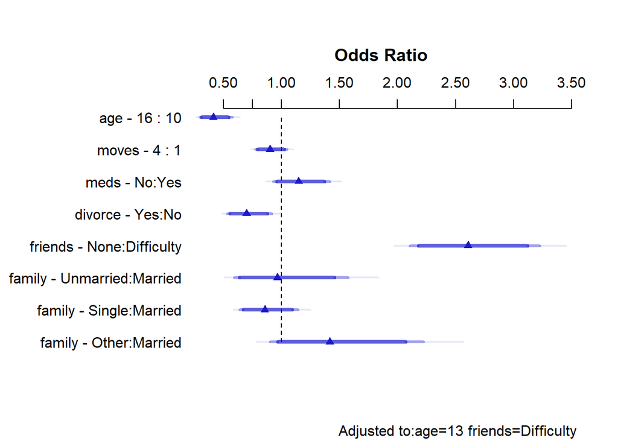

```r
plot(summary(mZ_lrm, conf.int = 0.90))
```

### 9.6.3 Numerical Description of Effect Sizes

```r
summary(mZ_lrm, conf.int = 0.90) |> kable(digits = 3)
```

|  | Low | High | Diff. | Effect | S.E. | Lower 0.9 | Upper 0.9 | Type |
| --- | --- | --- | --- | --- | --- | --- | --- | --- |
| age | 10 | 16 | 6 | -0.888 | 0.170 | -1.168 | -0.607 | 1 |
| Odds Ratio | 10 | 16 | 6 | 0.412 | NA | 0.311 | 0.545 | 2 |
| moves | 1 | 4 | 3 | -0.106 | 0.077 | -0.233 | 0.021 | 1 |
| Odds Ratio | 1 | 4 | 3 | 0.900 | NA | 0.792 | 1.021 | 2 |
| meds - No:Yes | 1 | 2 | NA | 0.137 | 0.107 | -0.039 | 0.314 | 1 |
| Odds Ratio | 1 | 2 | NA | 1.147 | NA | 0.961 | 1.369 | 2 |
| divorce - Yes:No | 2 | 1 | NA | -0.360 | 0.139 | -0.589 | -0.131 | 1 |
| Odds Ratio | 2 | 1 | NA | 0.698 | NA | 0.555 | 0.877 | 2 |
| friends - None:Difficulty | 1 | 2 | NA | 0.958 | 0.109 | 0.779 | 1.138 | 1 |
| Odds Ratio | 1 | 2 | NA | 2.608 | NA | 2.180 | 3.119 | 2 |
| family - Unmarried:Married | 1 | 2 | NA | -0.037 | 0.250 | -0.448 | 0.374 | 1 |
| Odds Ratio | 1 | 2 | NA | 0.964 | NA | 0.639 | 1.454 | 2 |
| family - Single:Married | 1 | 3 | NA | -0.157 | 0.148 | -0.400 | 0.086 | 1 |
| Odds Ratio | 1 | 3 | NA | 0.855 | NA | 0.670 | 1.090 | 2 |
| family - Other:Married | 1 | 4 | NA | 0.348 | 0.231 | -0.032 | 0.727 | 1 |
| Odds Ratio | 1 | 4 | NA | 1.416 | NA | 0.969 | 2.069 | 2 |

### 9.6.4 Effect Size Description

For the following effect size estimates, we will use two subjects. These two subjects are named Matilda and Mara.

### 9.6.6 Nomogram of Winning Model

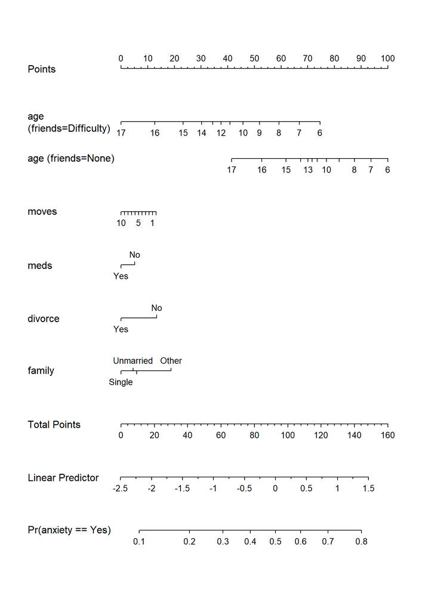

```r
plot(nomogram(mZ_lrm, fun = plogis,
              funlabel = "Pr(anxiety == Yes)"))
```

According to this nomogram, my model shows that no difficulty making or keeping friendships leads to a higher risk for anxiety than those difficulty. It also shows that as the number of moves someone has experienced increases, the probability of anxiety decreases. Medication is also associated with reduced probability of anxiety, while not taking medication has a higher probability. Divorce is shown here as having a protective effect, with my model predicting that not experiencing divorce would lead to a higher probability of anxiety. Lastly, a family structure other than single, unmarried, or married is shown to correspond with a higher probability of anxiety.

### 9.6.7 Predictions for Two New Subjects

```r
new_subs <-
  data.frame(age = c(12, 12), meds = c("Yes", "Yes"), divorce = c("Yes","No"), moves = c(3, 3), friends = c("None","None"), family = c("Single","Single"))

new_subs <- new_subs %>% mutate(across(where(is.character), as.factor))

pred3 <- predict(mY, newdata = new_subs, type = "response")

pred3
```

```
        1         2
0.4160407 0.5043267
```

There are two subjects in this prediction, whom we will call Agatha and Christie. We can say that they are both 12 years old, currently take medication for ADD/ADHD, have moved addresses 3 times, have no difficulty making friends, and live in a single-parent household. However, Agatha has experienced the divorce of a parent, while Christie has not. According to the predicted values above, the risk for anxiety in Agatha is 0.42, while it is 0.50 for Christie.

# 10 Discussion

## 10.1 Answering My Research Questions

Can height be effectively predicted using age, ADD/ADHD medication status, low birth weight, and sleep patterns in female children with ADD or ADHD, between the ages of 6-17?

How effectively can an anxiety diagnosis be predicted via age, use of ADD/ADHD medication, family structure, divorce, times moved, difficulty making friends, and hours of sleep in female children between the ages of 6-17?

An anxiety diagnosis may be able to be predicted via these factors, but my models need to be extensively verified to rule out them being incorrect for the analysis of this question. My models predicted very counterintuitive results, which could be exciting if there was no existing literature clearly going against their claims. My model predicted that higher number of moves, occurrence of divorce, and difficulty making or keeping friendships lessened probability of anxiety, which is not the direction I had anticipated, to say the least.

## 10.2 Thoughts on Project A

Question 3: What was the most confusing part of doing the project, and how did you get past it?

The title for most confusing part of this project is tied for me between data cleaning and trying to understand my results for the logistic regression analysis. My results for the logistic regression were completely counterintuitive, which led me to spend too much time reloading my data in different ways and try different ways of cleaning/organizing variables, to no avail. I decided to simply interpret it the way it was and mention they are counterintuitive in my interpretation.

Question 4: What was the most useful thing you learned while doing the project, and why?

The most useful thing I learned in this project is that, when dealing with raw data, there are so many unknown obstacles you can encounter *just* in the ingesting and cleaning process. I realize this is likely a no-brainer, but this was the first time I had ever ingested, cleaned, and organized data from a data set that was not provided to me. Having to make sure I understood how each variable was collected, how it was coded, check for explanations of any recoding the collecting institution may have done was all extremely new to me.

# 11 Affirmation

I am certain that it is completely appropriate for these data to be shared with anyone, without any conditions. There are no concerns about privacy or security.

# 12 References

1. The National Survey of Children’s Health (NSCH) is an annual survey, conducted by the U.S. Census Bureau. This survey collects national and state data on health factors and well-being for children between the ages of 0-17 years. Data is collected via mailed surveys or online surveys provided via a mailed invitation (including a screener questionnaire to determine household child eligibility for subsampling). https://www.census.gov/programs-surveys/nsch.html